# NFL 2020 Week 10

# Cadet Individual Results

MA206 Individual Results

Week 10

Name

Weekly # Correct

Percent

Weeks Picked

Season Percent

Adj Season Percent

Season Trend

Week 1

Week 2

Week 3

Week 4

Week 5

Week 6

Week 7

Week 8

Week 9

Week 10

Thomas Bizub

10

14

8

11

8

9

10

8

10

12

0.8571

10

0.6849

0.6849

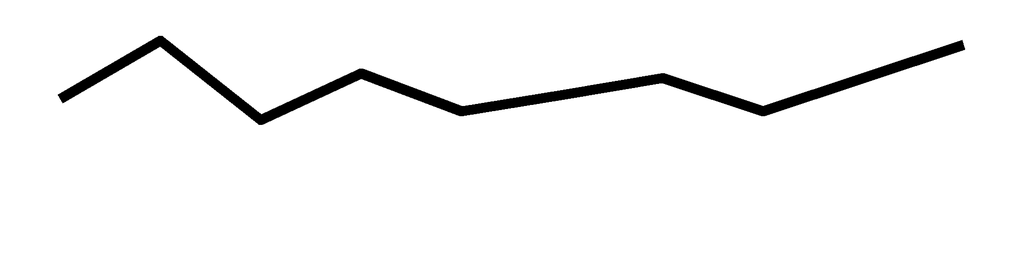

Sydney Shannon

10

9

8

9

8

7

9

5

8

10

0.7143

10

0.5685

0.5685

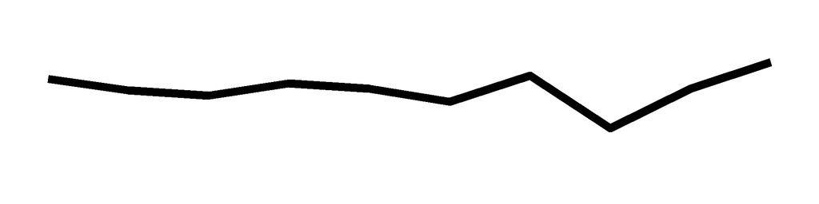

Caroline Swenson

8

12

11

13

7

8

10

NA

8

9

0.6429

9

0.6515

0.5864

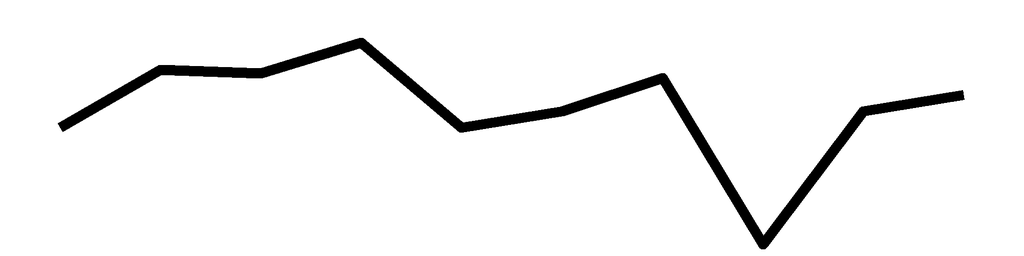

John White

10

11

10

8

12

9

11

6

9

9

0.6429

10

0.6507

0.6507

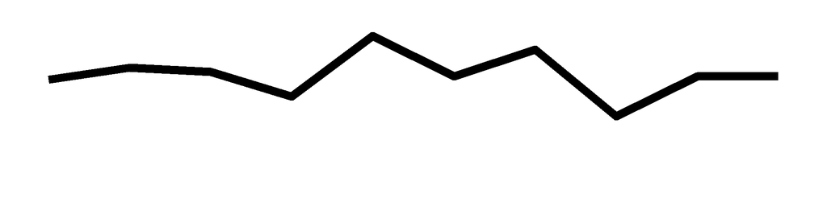

Christopher Erb

9

9

7

11

9

11

8

11

10

9

0.6429

10

0.6438

0.6438

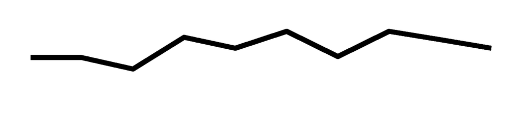

Victor Olawale-Apanpa

8

NA

10

NA

10

NA

10

7

7

9

0.6429

7

0.6040

0.4228

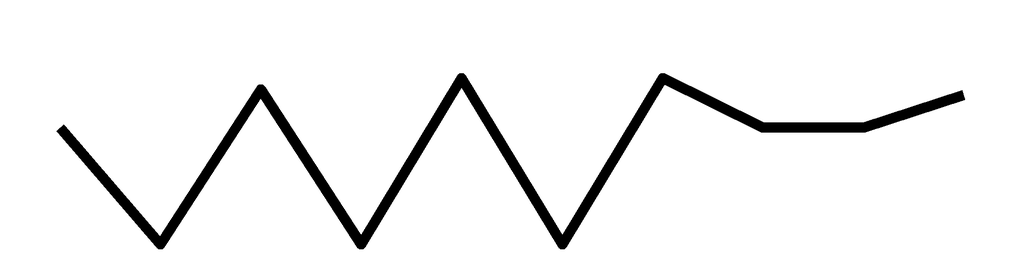

Zakai Bufkin

8

11

7

9

8

10

9

7

9

9

0.6429

10

0.5959

0.5959

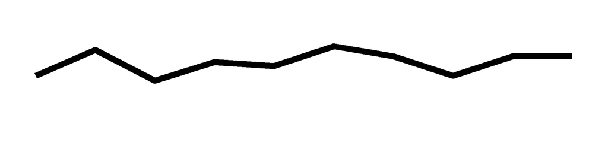

Laurence Dowd

10

10

10

9

10

NA

12

NA

10

8

0.5714

8

0.6695

0.5356

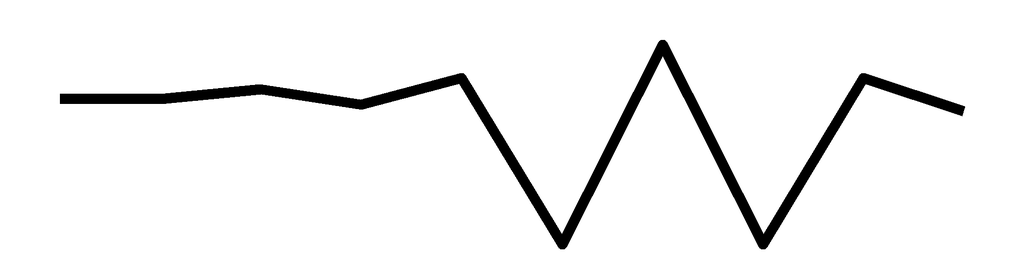

Paige Lennon

NA

NA

NA

11

10

8

11

8

6

8

0.5714

7

0.6263

0.4384

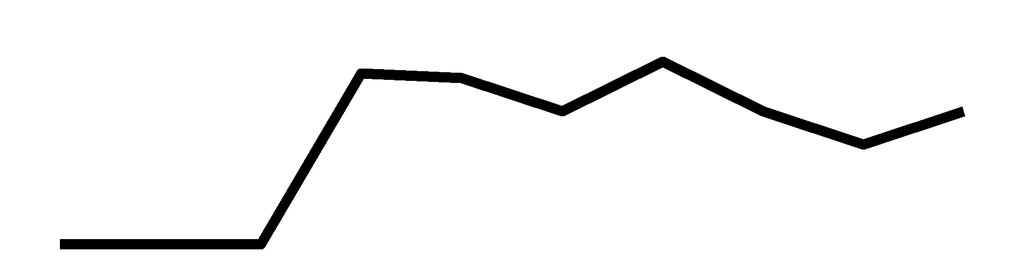

Sidney Cash

10

10

NA

10

NA

8

8

7

11

8

0.5714

8

0.6154

0.4923

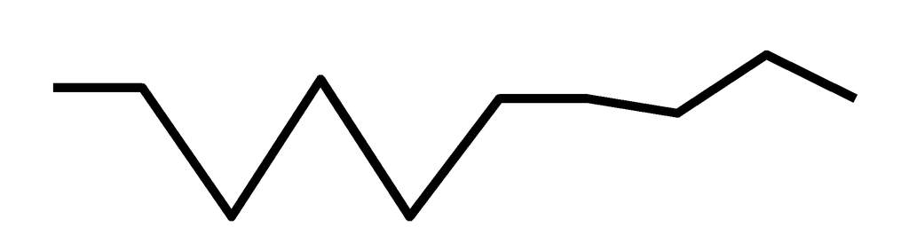

Gabriela Peralta

11

8

9

NA

8

8

10

6

NA

8

0.5714

8

0.5812

0.4650

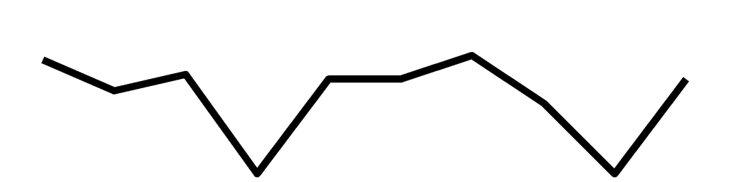

Joshua Loyd

11

9

8

NA

6

9

NA

6

10

8

0.5714

8

0.5726

0.4581

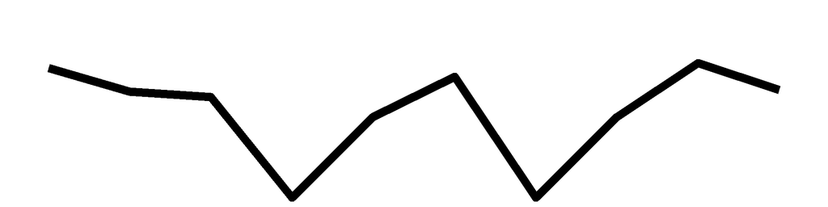

Joshua Gilliard

9

8

9

10

10

7

10

7

5

8

0.5714

10

0.5685

0.5685

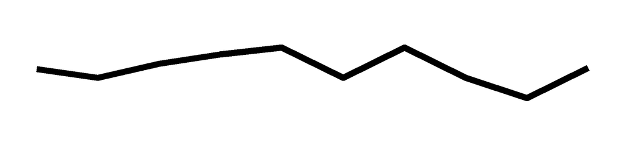

Jonathan Kemp

10

10

NA

NA

11

10

11

7

8

6

0.4286

8

0.6293

0.5034

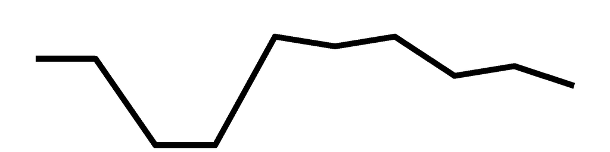

Ryan Jackovic

11

10

NA

7

7

8

8

7

NA

4

0.2857

8

0.5299

0.4239

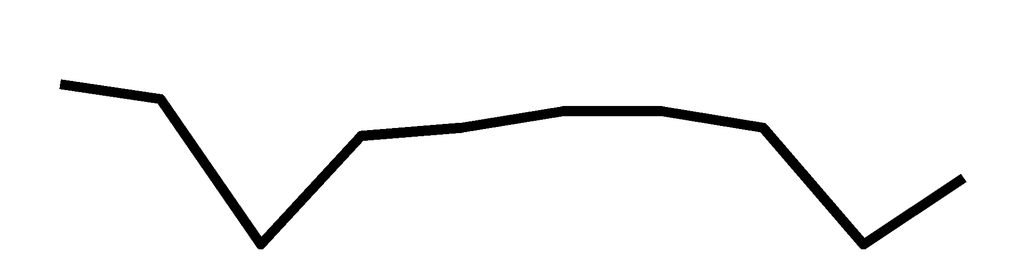

Kieran Place

12

11

8

NA

10

10

9

NA

NA

NA

0.0000

6

0.6742

0.4045

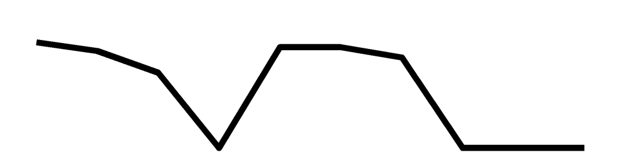

Luca Testa

NA

NA

10

NA

NA

NA

NA

NA

NA

NA

0.0000

1

0.6667

0.0667

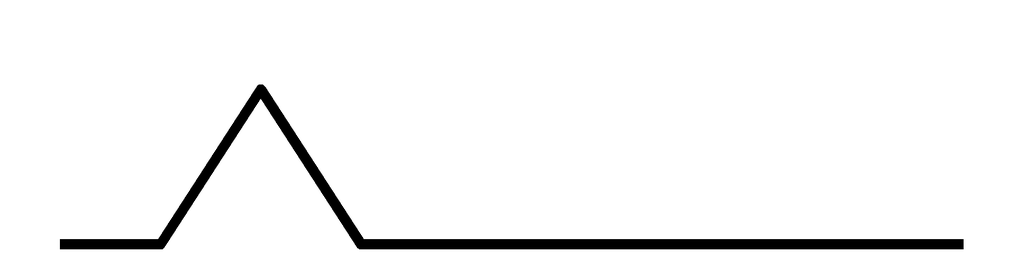

Cameron Patterson

11

9

8

NA

NA

NA

NA

NA

NA

NA

0.0000

3

0.5957

0.1787

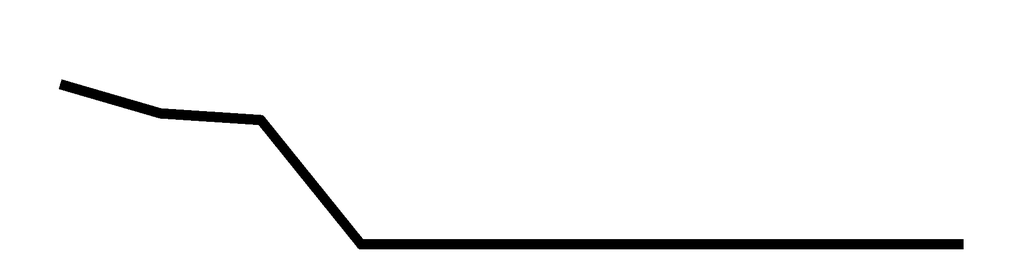

Amadou Bah

9

NA

NA

NA

NA

NA

NA

NA

NA

NA

0.0000

1

0.5625

0.0562

Margaret Williams

9

NA

NA

NA

NA

NA

NA

NA

NA

NA

0.0000

1

0.5625

0.0562

Logan Kauina

9

NA

NA

NA

NA

NA

NA

NA

NA

NA

0.0000

1

0.5625

0.0562

Caleb John

NA

9

NA

NA

NA

NA

NA

NA

NA

NA

0.0000

1

0.5625

0.0562

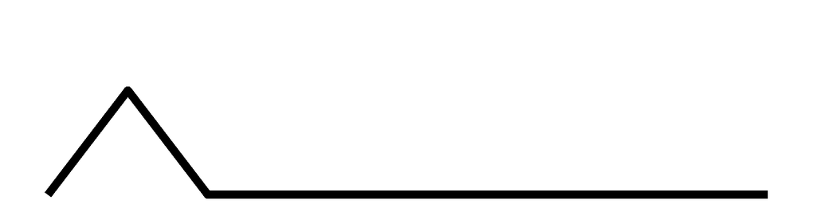

Jay Hajost

11

7

10

NA

6

NA

NA

7

9

NA

0.0000

6

0.5618

0.3371

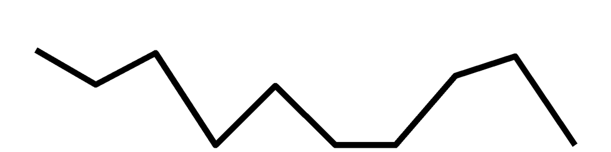

August Rannow

9

NA

NA

NA

7

NA

NA

NA

NA

NA

0.0000

2

0.5333

0.1067

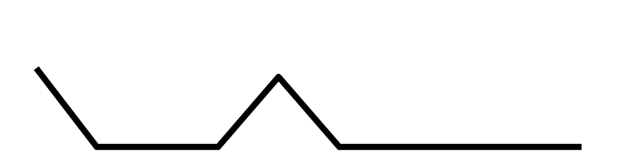

Peter Digenan

9

6

8

10

7

NA

NA

NA

NA

NA

0.0000

5

0.5263

0.2632

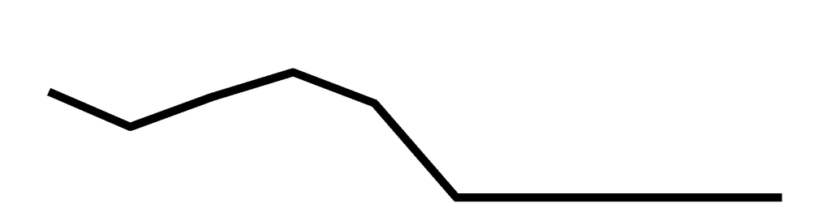

Caleb Doyle

9

NA

NA

NA

NA

NA

NA

6

NA

NA

0.0000

2

0.5000

0.1000

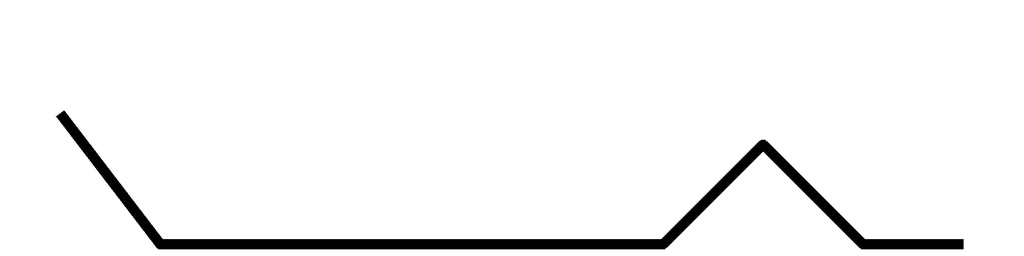

Sydney Johnson

NA

NA

NA

NA

NA

NA

NA

6

NA

NA

0.0000

1

0.4286

0.0429

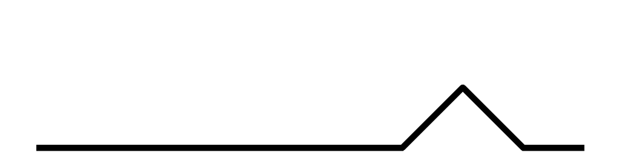

Congrats Thomas Bizub for having the best cadet picks this week, with a correct percentage of 0.8571

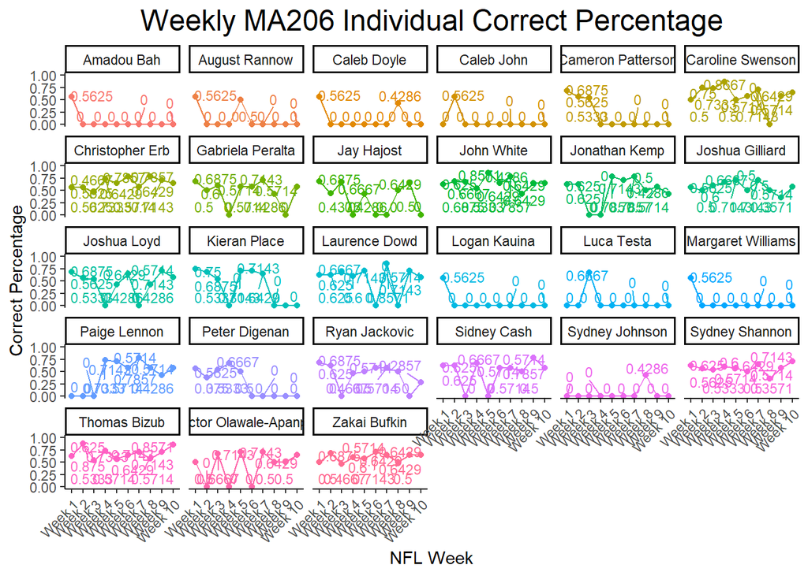

## Combined cadet and instructor prediction

This Week's Combined Cadet and Instructor Predictions

Week 10

| Game | Prediction | Winner | Correct | Correct Votes | Correct Percent |
| --- | --- | --- | --- | --- | --- |
| 1 | Tennessee Titans | Indianapolis Colts | No | 4 | 0.1212 |
| 2 | Green Bay Packers | Green Bay Packers | Yes | 32 | 0.9697 |
| 3 | Cleveland Browns | Cleveland Browns | Yes | 30 | 0.9091 |
| 4 | Philadelphia Eagles | New York Giants | No | 6 | 0.1818 |
| 5 | Tampa Bay Buccaneers | Tampa Bay Buccaneers | Yes | 32 | 0.9697 |
| 6 | Detroit Lions | Detroit Lions | Yes | 27 | 0.8182 |
| 7 | Miami Dolphins | Miami Dolphins | Yes | 29 | 0.8788 |
| 8 | Las Vegas Raiders | Las Vegas Raiders | Yes | 31 | 0.9394 |
| 9 | Buffalo Bills | Arizona Cardinals | No | 7 | 0.2121 |
| 10 | Pittsburgh Steelers | Pittsburgh Steelers | Yes | 31 | 0.9394 |
| 11 | Seattle Seahawks | Los Angeles Rams | No | 6 | 0.1818 |
| 12 | New Orleans Saints | New Orleans Saints | Yes | 32 | 0.9697 |
| 13 | Baltimore Ravens | New England Patriots | No | 1 | 0.0303 |
| 14 | Chicago Bears | Minnesota Vikings | No | 8 | 0.2424 |

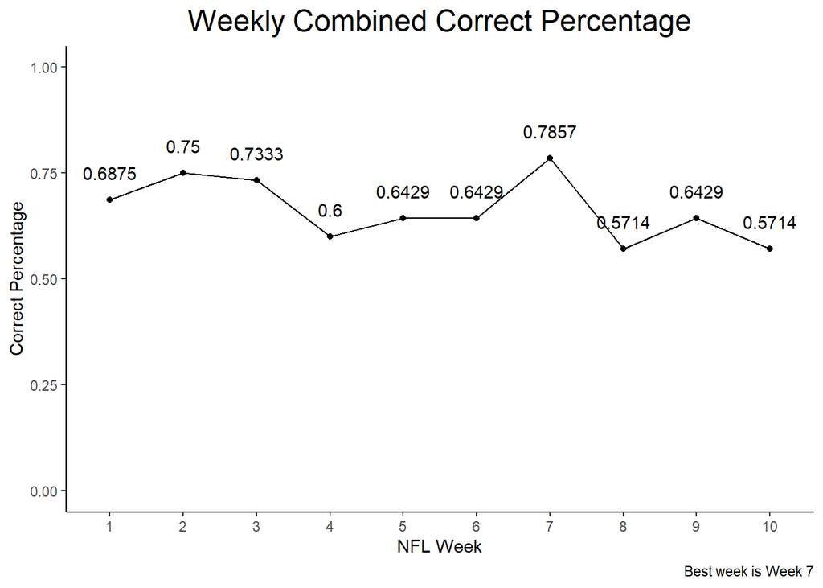

Our combined win percentage for the week is 0.5714

Our season combined win percentage so far is 0.6644

33 total predictions this week

This Week's Matched Cadet and Instructor Predictions

Week 10

| Game | Prediction | Correct |
| --- | --- | --- |
| 1 | Tennessee Titans | No |
| 2 | Green Bay Packers | Yes |
| 3 | Cleveland Browns | Yes |
| 4 | Philadelphia Eagles | No |
| 5 | Tampa Bay Buccaneers | Yes |
| 6 | Detroit Lions | Yes |
| 7 | Miami Dolphins | Yes |
| 8 | Las Vegas Raiders | Yes |
| 9 | Buffalo Bills | No |
| 10 | Pittsburgh Steelers | Yes |
| 11 | Seattle Seahawks | No |
| 12 | New Orleans Saints | Yes |
| 13 | Baltimore Ravens | No |
| 14 | Chicago Bears | No |

[figure not shown]

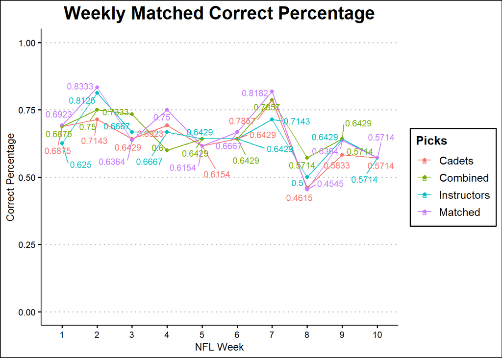